# Electoral Division Health Profile for Killannin, Galway County

[figure not shown]

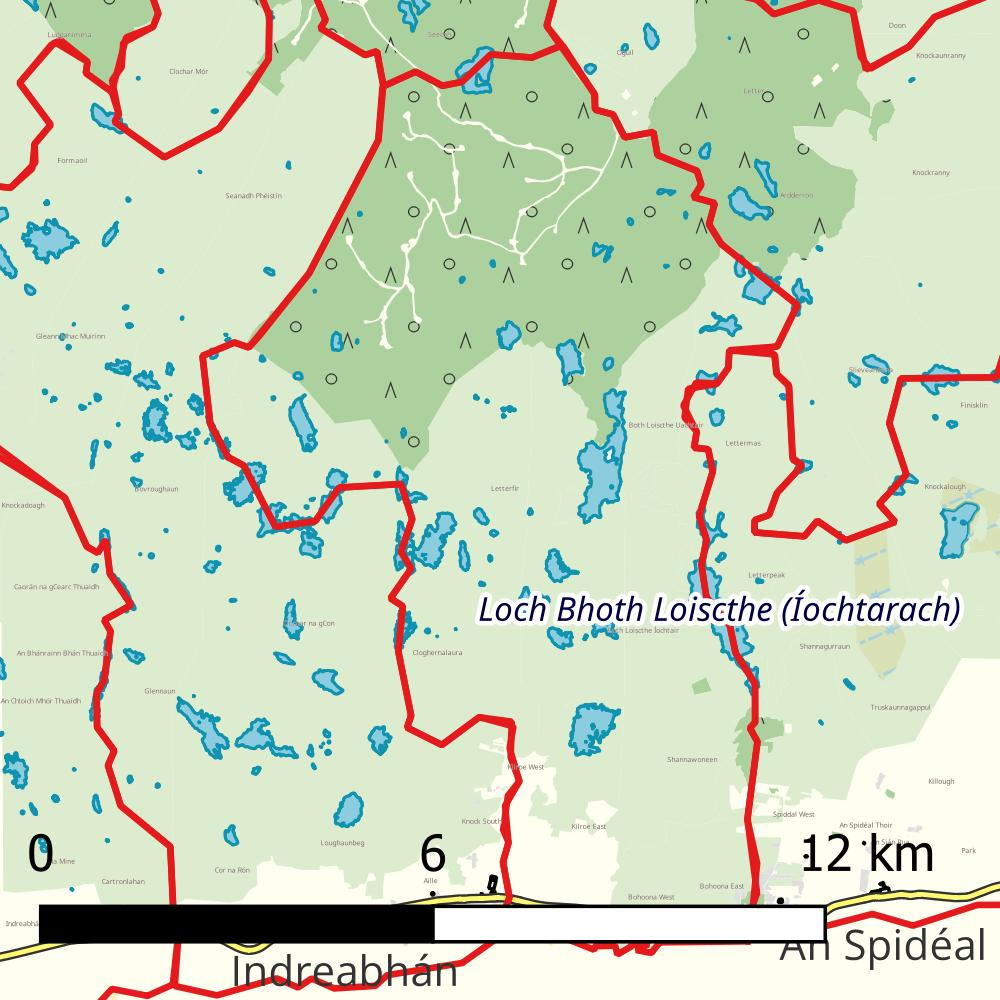

Figure 1. Boundary Map for Killannin, Galway County Electoral Division (Sources: OSI, Ireland; OpenStreetMap). Map style by Champs-Libres Coop., distributed under CC BY-SA.

Census 2022

CSO, Ireland (http://www.cso.ie)

A more detailed and print friendly pdf profile - with accompanying tables - is available here.

*Note: This is the first time this profle has been compiled. While effort has been made to ensure this document is error free, it is possible that there may be some. Please email tomas.kelly@cso.ie if you observe any errors or inconsistencies with other CSO data.*

# 1 Key Points

- Killannin, Galway County covers a total **area** of **70.1** square kilometers and has a **population density** of **15.8** persons per square kilometer. The population density of Ireland as a whole is 73.3.
- The **Age Dependency Ratio of this Electoral Division (ED) is** **67.1**. This compares to 53.2 nationally. The Age Dependency Ratio is the amount of people outside of working age (0-14 and 65+) per 100 people of working age (15-64).
- Killannin, Galway County has a total of **1108 persons** and **283 families** living in private households.
- There are a total of **207 persons aged 0-14** in this ED and **238 persons aged over 65**.
- There are a total of **215 persons living with a disability** in this ED, representing **19.4 percent** of the population. This compares with , 21.5, percent nationally
- **10 people** in this ED have **bad or very bad general health**. This represents **0.9 percent** of the population. 1.7 percent of the population have bad or very bad general health nationally.
- There are a total of **99 carers** in this ED, representing **8.9 percent** of the population. This compares with 5.8 percent of the population that are carers nationally.
- **11.1 percent** of this ED **smoke tobacco products**. 13.1 percent of people nationally smoke tobacco products
- There are **16 short term unemployed** and **23 long term unemployed** people in this ED. These represent **1.8** and **2.6** percent of the population respectively.
- **5.0 percent** of the population of Killannin, Galway County are **unskilled**. 3.1 percent of people in the state are unskilled.
- **20.2 percent** of those aged 15+ in this ED have a **highest level of education of lower secondary or lower**. This compares with 23 percent nationally.
- **16.8 percent** of families with children in this ED have **lone parents**. This stands at 24.8 nationally.
- **13.8 percent** of this ED were **born outside Ireland** (20 percent nationally).
- **Households rented from a Local Authority** comprise **0.7 percent** of households in this ED.This stands at 8.3 percent nationally

# 2 Population

[figure not shown]

Figure 2. Persons by Age Group and Gender for Killannin, Galway County; Administrative County and State; Census 2022.

# 3 Disability

[figure not shown]

Figure 3. Percentage of Population with any Disability by Age Group for Killannin, Galway County; Administrative County and State; Census 2022.

# 4 General Health

[figure not shown]

Figure 4. Population Breakdown (%) by General Health for Killannin, Galway County; Administrative County and State; Census 2022.

# 5 Carers

[figure not shown]

Figure 5. Carers as a Percentage of the Population of Males/Females/Both Sexes for Killannin, Galway County; Administrative County and State; Census 2022.

# 6 Volunteers

[figure not shown]

Figure 6. Volunteers as a Percentage of the Population for Killannin, Galway County; Administrative County and State; Census 2022.

# 7 Smoking

[figure not shown]

Figure 7. Percentage of the Population who Smoke Tobacco Products (Daily and Occasionally) for Killannin, Galway County; Administrative County and State; Census 2022.

# 8 Principal Economic Status

[figure not shown]

Figure 8. Percentage of Population Aged 15+ by Principal Economic Status for Killannin, Galway County; Administrative County and State; Census 2022.

# 9 Social Class

[figure not shown]

Figure 9. Percentage of Population Aged 15+ by Social Class for Killannin, Galway County; Administrative County and State; Census 2022.

# 10 Education

[figure not shown]

Figure 10. Percentage of Population Aged 15+ by Highest Level of Education Completed for Killannin, Galway County; Administrative County and State; Census 2022.

# 11 Families

[figure not shown]

Figure 11. Percentage of Families with Children by Family Type for Killannin, Galway County; Administrative County and State; Census 2022.

# 12 Birthplace

[figure not shown]

Figure 12. Percentage of Usually Resident Population by Birthplace for Killannin, Galway County; Administrative County and State; Census 2022.

# 13 Households - Type of Occupancy

[figure not shown]

Figure 13. Percentage of Households by Type of Occupancy for Killannin, Galway County Administrative County and State; Census 2022.

# 14 Transport

[figure not shown]

Figure 14. Percentage of Usually Resident Population by Means of Travel to Work, School, College or Childcare for Killannin, Galway County; Administrative County and State; Census 2022.

# 15 Renewable Energy

[figure not shown]

Figure 15. Percentage of Households by Renewable Energy Source for Killannin, Galway County; Administrative County and State; Census 2022.